# Normal distribution

Teodor Petrič

2021-6-14

# 0. Packages

```r
library(tidyverse)
```

# 0. Data

```r
metode <- read.csv("data/ttest2a.csv", dec=",")
glimpse(metode)
```

```
## Rows: 40
## Columns: 3
## $ Testpersonen <int> 1, 2, 3, 4, 5, 6, 7, 8, 9, 10, 11, 12, 13, 14, 15, 16, 17~
## $ Resultat     <int> 23, 34, 54, 33, 26, 27, 29, 37, 44, 22, 19, 16, 40, 38, 3~
## $ Methode      <chr> "A", "A", "A", "A", "A", "A", "A", "A", "A", "A", "A", "A~
```

```r
mean(metode$Resultat)
```

```
## [1] 32.1
```

```r
sd(metode$Resultat)
```

```
## [1] 8.860167
```

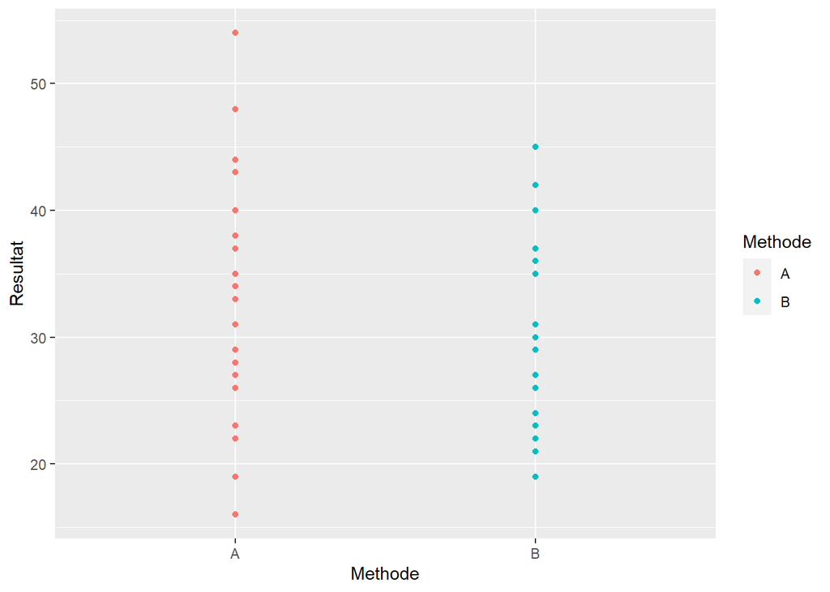

```r
qplot(Methode, Resultat, color = Methode, data = metode)
```

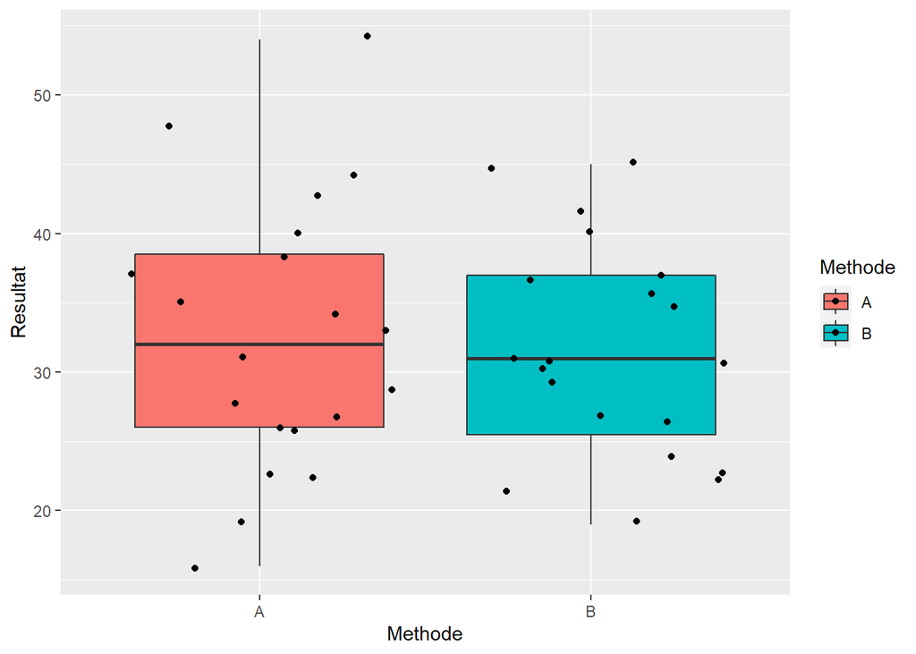

```r
qplot(Methode, Resultat, fill = Methode, geom = c("boxplot", "jitter"),
      data = metode) # facets = Resultat ~ Methode,
```

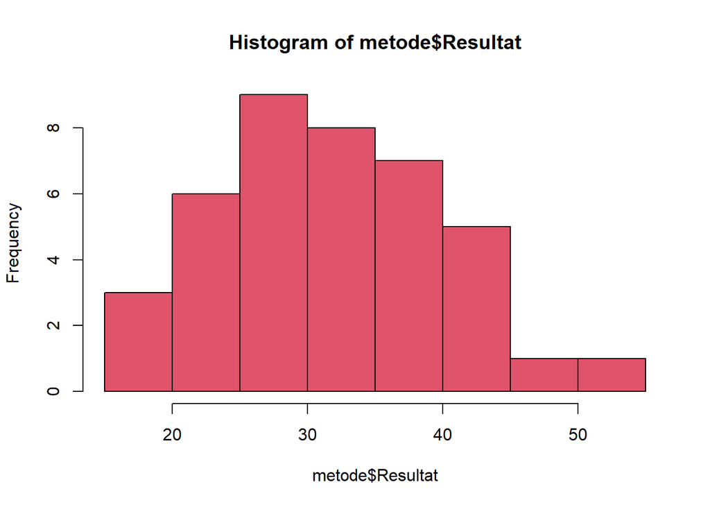

```r
hist(metode$Resultat, col = 2)
```

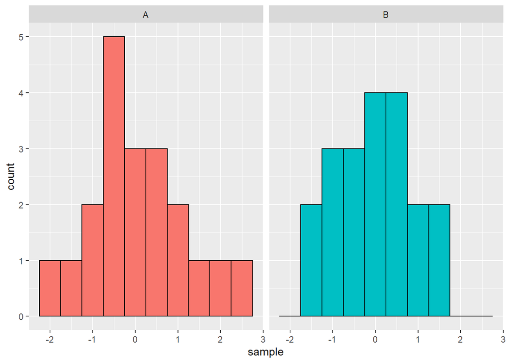

```r
metode %>%
  mutate(sample = scale(Resultat)) %>%
  ggplot(aes(sample, fill = Methode)) +
  geom_histogram(binwidth = 0.5, color = "black") +
  facet_wrap(~ Methode) +
  theme(legend.position = "none")
```

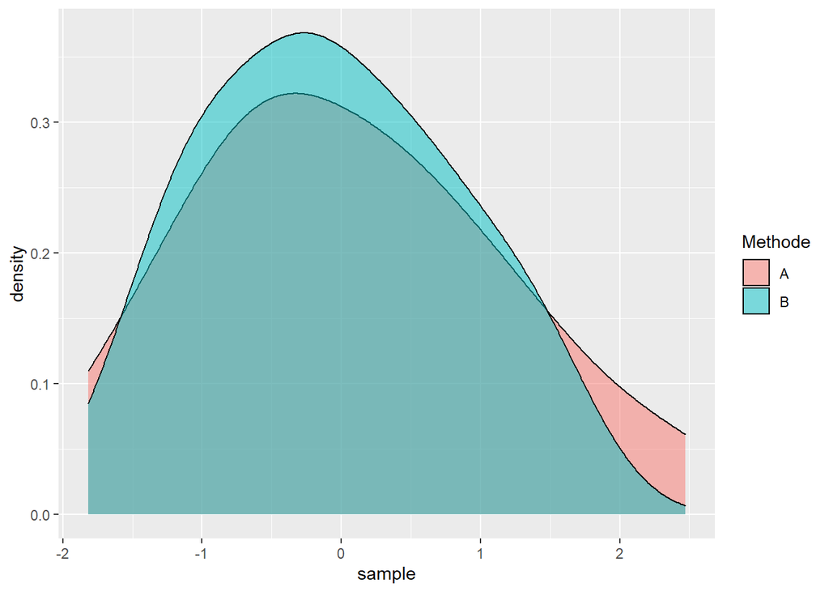

```r
metode %>%
  mutate(sample = scale(Resultat)) %>%
  ggplot(aes(sample, fill = Methode)) +
  geom_density(alpha = 0.5)
```

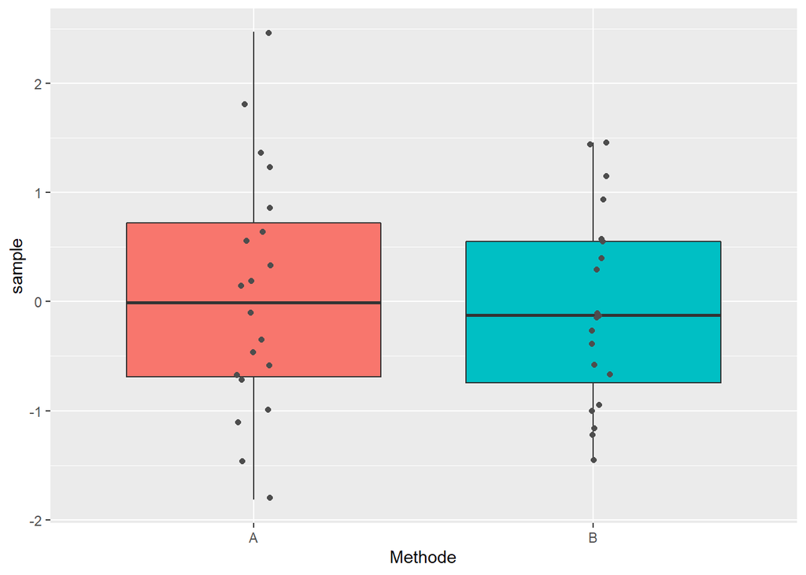

```r
metode %>%
  mutate(sample = scale(Resultat)) %>%
  ggplot(aes(Methode, sample, fill = Methode)) +
  geom_boxplot() +
  # geom_tile(stat = "identity") +
  geom_jitter(width = 0.05, color = "grey30") +
  theme(legend.position = "none")
```

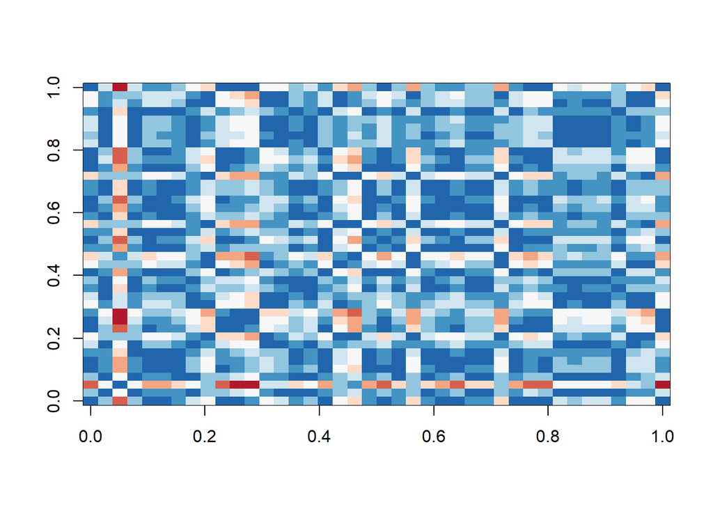

```r
x <- metode[,2] %>% as.matrix()
d <- dist(x)
image(as.matrix(d), col = rev(RColorBrewer::brewer.pal(9, "RdBu")))
```

# 1. Normal distribution

https://pubs.wsb.wisc.edu/academics/analytics-using-r-2019/

The normal distribution is used if the variable is continuous. We usually refer to the density of a normal random variable as a bell-shaped curve. We require a value for the mean and another for the standard deviation to simulate a value from a normal distribution.(The mean and standard deviation (or variance) are the parameters of a normal distribution.)

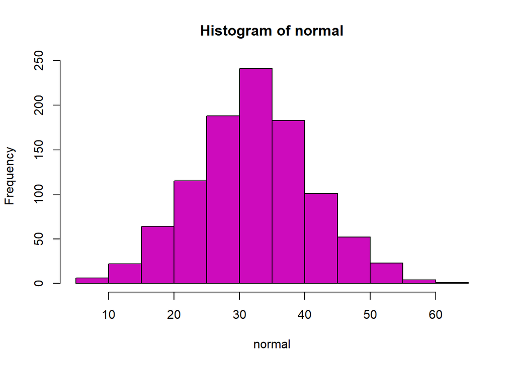

```r
set.seed(123)
normal <- rnorm(n = 1000, mean = 32, sd = 9)
hist(normal, breaks = 10, col = 6)
```

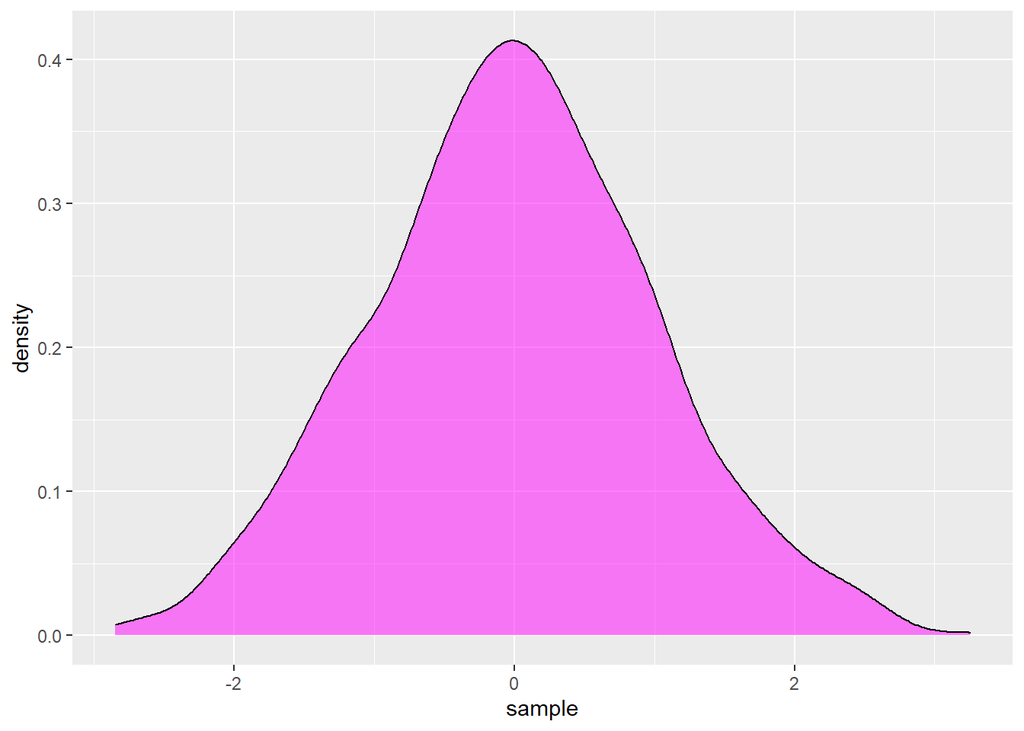

```r
as.data.frame(normal) %>%
  mutate(sample = scale(normal)) %>%
  ggplot(aes(sample)) +
  geom_density(fill = "magenta", alpha = 0.5) +
  theme(legend.position = "none")
```

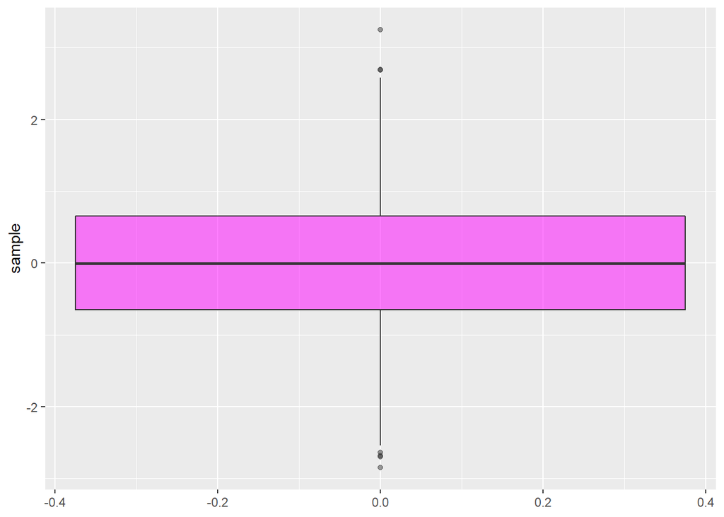

```r
as.data.frame(normal) %>%
  mutate(sample = scale(normal)) %>%
  ggplot(aes(y = sample)) +
  geom_boxplot(fill = "magenta", alpha = 0.5) +
  theme(legend.position = "none")
```

```r
# install.packages("psych)
library(psych)
describe(normal)
```

```
##    vars    n  mean   sd median trimmed  mad  min   max range skew kurtosis   se
## X1    1 1000 32.15 8.93  32.08   32.08 8.68 6.71 61.17 54.46 0.07    -0.08 0.28
```

## t test

No significant difference (p = 0.975):

```r
t.test(metode$Resultat, normal)
```

```
##
##  Welch Two Sample t-test
##
## data:  metode$Resultat and normal
## t = -0.031595, df = 42.228, p-value = 0.9749
## alternative hypothesis: true difference in means is not equal to 0
## 95 percent confidence interval:
##  -2.928659  2.838357
## sample estimates:
## mean of x mean of y
##  32.10000  32.14515
```

## Normality test

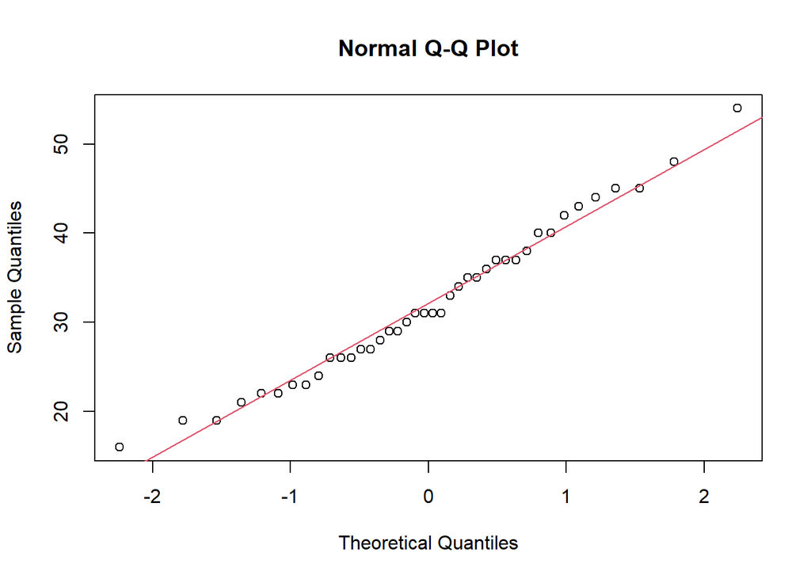

```r
qqnorm(metode$Resultat)
qqline(normal, distribution = qnorm, probs = c(0.25, 0.75), qtype = 7, col = 2, lty = 1)
```

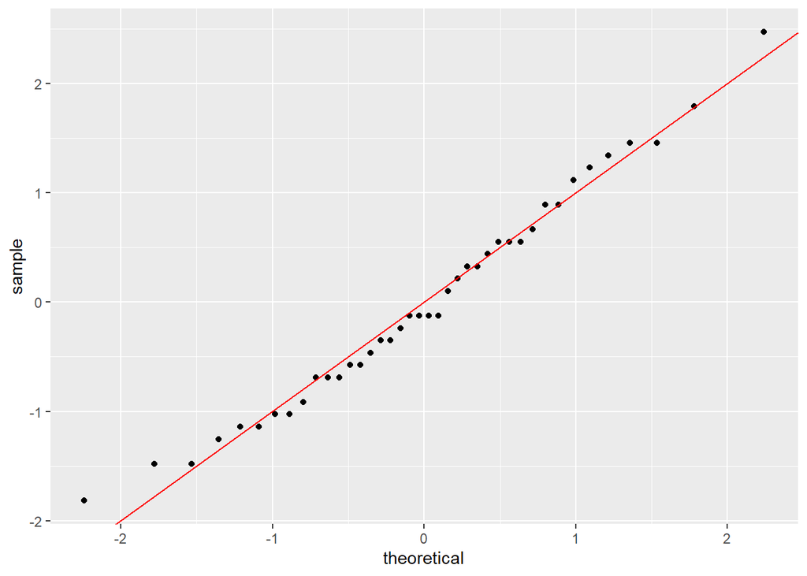

```r
params <- metode %>%
  summarise(mean = mean(Resultat), sd = sd(Resultat))

metode %>% group_by(Methode) %>%
  ggplot(aes(sample = scale(Resultat))) +
  geom_qq(distribution = qnorm, line.p = c(0.25, 0.75)) +
  geom_abline(color = "red")
```

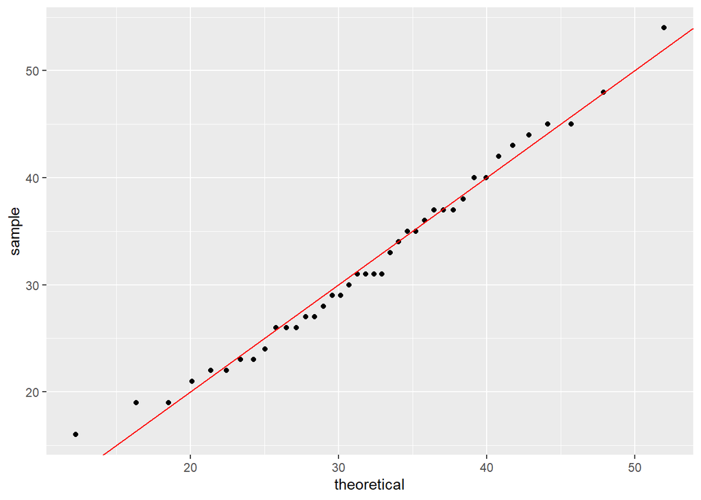

```r
metode %>% group_by(Methode) %>%
  ggplot(aes(sample = (Resultat))) +
  geom_qq(dparams = params) +
  geom_abline(color = "red")
```

```r
shapiro.test(metode$Resultat)
```

```
##
##  Shapiro-Wilk normality test
##
## data:  metode$Resultat
## W = 0.98104, p-value = 0.7279
```

```r
shapiro.test(normal)
```

```
##
##  Shapiro-Wilk normality test
##
## data:  normal
## W = 0.99838, p-value = 0.4765
```

## Regression

No significant difference between method A and B.

```r
model <- lm(Resultat ~ Methode, data = metode)
summary(model)
```

```
##
## Call:
## lm(formula = Resultat ~ Methode, data = metode)
##
## Residuals:
##    Min     1Q Median     3Q    Max
## -16.65  -6.65  -0.55   5.45  21.35
##
## Coefficients:
##             Estimate Std. Error t value Pr(>|t|)
## (Intercept)   32.650      2.003  16.300   <2e-16 ***
## MethodeB      -1.100      2.833  -0.388      0.7
## ---
## Signif. codes:  0 '***' 0.001 '**' 0.01 '*' 0.05 '.' 0.1 ' ' 1
##
## Residual standard error: 8.958 on 38 degrees of freedom
## Multiple R-squared:  0.003952,   Adjusted R-squared:  -0.02226
## F-statistic: 0.1508 on 1 and 38 DF,  p-value: 0.7
```

# 2. Chi squared distribution

cf. https://pubs.wsb.wisc.edu/academics/analytics-using-r-2019/

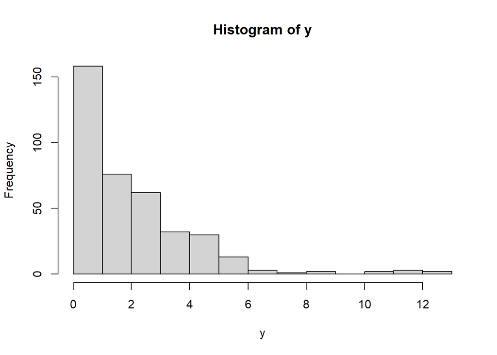

```r
set.seed(2)
y <- rchisq(384, df = 2)
hist(y)
```

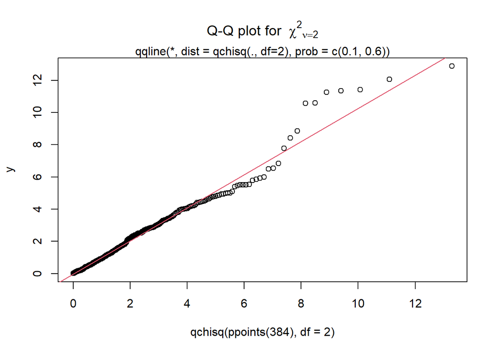

```r
## Q-Q plot for Chi^2 data against true theoretical distribution:
qqplot(qchisq(ppoints(384), df = 2), y,
       main = expression("Q-Q plot for" ~~ {chi^2}[nu == 2]))
qqline(y, distribution = function(p) qchisq(p, df = 2),
       probs = c(0.1, 0.6), col = 2)
mtext("qqline(*, dist = qchisq(., df=2), prob = c(0.1, 0.6))")
```

```r
## (Note that the above uses ppoints() with a = 1/2, giving the
## probability points for quantile type 5: so theoretically, using
## qqline(qtype = 5) might be preferable.)
```

# 3. Binomial distribution

cf. https://pubs.wsb.wisc.edu/academics/analytics-using-r-2019/

A special case of a categorical variable is an indicator variable, sometimes referred to as a binary or dummy variable. The underlying distribution of an indicator variable is called a Bernoulli distribution.

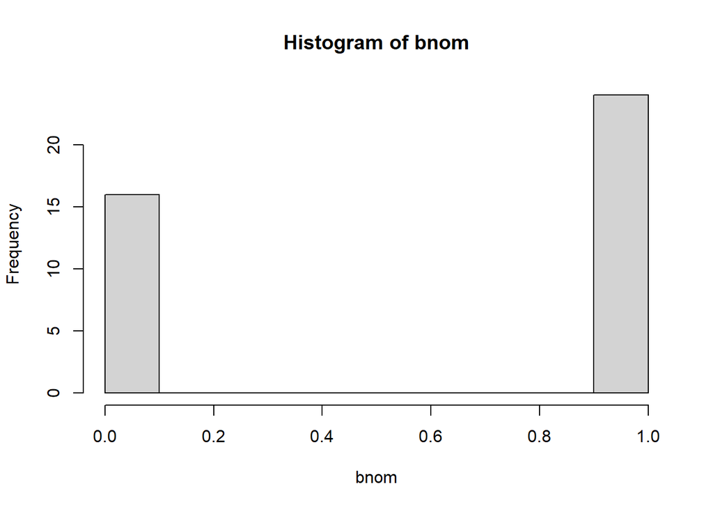

```r
set.seed(123)
# Simulating indicator variables is completed using the rbinom function. Here, we simulate 5 values of heads with a probability of 1/2 of getting a head on each flip
bnom <- rbinom(n = 40, size = 1, prob = 0.5)
hist(bnom, breaks = 10)
```

```r
library(psych)
describe(bnom)
```

```
##    vars  n mean  sd median trimmed mad min max range  skew kurtosis   se
## X1    1 40  0.6 0.5      1    0.62   0   0   1     1 -0.39    -1.89 0.08
```

# 4. Poisson distribution

cf. https://pubs.wsb.wisc.edu/academics/analytics-using-r-2019/

Another discrete distribution that you may learn is called the Poisson distribution that is used to predict counts of some event that occur within a given time interval. For example, recording the number of car accidents that you have in a year.

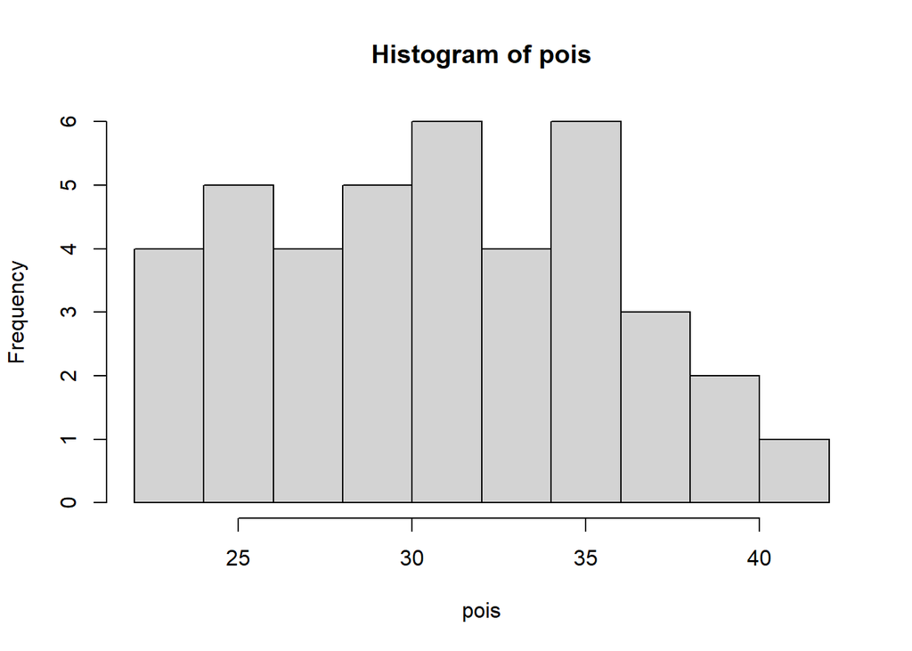

```r
set.seed(123)
# Here in addition to the number of values to simulate, we just need the parameter for the mean (called lambda).
pois <- rpois(n = 40, lambda = 32)
hist(pois, breaks = 10)
```

```r
library(psych)
describe(pois)
```

```
##    vars  n  mean  sd median trimmed  mad min max range  skew kurtosis   se
## X1    1 40 31.18 5.1     31   31.19 5.93  22  41    19 -0.03    -1.08 0.81
```

# 5. Gamma distribution

cf. https://pubs.wsb.wisc.edu/academics/analytics-using-r-2019/

Another continuous distribution that you may learn is called the Gamma distribution. This distribution is used for random variables that have some skewness and is not symmetrical, like the Normal Distribution.

The Gamma distribution requires a little more background to understand how to define the parameters.

There is a R function for simulating this random variable. Here in addition to the number of values to simulate, we just need two parameters, one for the shape and one for either the rate or the scale. The rate is the inverse of the scale. The general formula is: rgamma(n, shape, rate = 1, scale = 1/rate).

Given that α is the shape parameter and β is the rate or scale parameter, then if you are thinking of a Gamma random variable, where the mean = α∗β, then you use the scale for simulating. Otherwise, you use the rate.

```r
set.seed(1)
x <- rgamma(n = 40, shape = 3, scale = 2)
# And verifying the mean equal to 6 (shape*scale):
mean(x)
```

```
## [1] 5.576655
```

```r
set.seed(1)
x <- rgamma(n = 40, shape = 3, rate = 0.5)
# Or verifying the mean equal to 6 (shape*1/rate):
mean(x)
```

```
## [1] 5.576655
```